# 0012_the_predicted_network

Dan MacLean

2018-08-14

## Loading the predicted network

The prediction of TF/Target pairs was done outside the markdown using the script `scripts/run_tf_predict.R`.

```bash
Rscript scripts/run_tf_predict.R
```

This produced the file “predictions.csv”, which has the columns

| TF_AGI | TARGET_AGI | TF_affy | TARGET_affy | prediction | likelihood |
| --- | --- | --- | --- | --- | --- |
| NA | NA | NA | NA | NA | NA |

I’ll load the predictions with likelihood >= 0.99 into a dataframe and process into a graph. I’ll reorder to use the affy names as id, since they’re unique.

```r
interactions_df <- readr::read_csv("../data/predictions.csv",
                col_names = c("TF_AGI", "Target_AGI",
                              "TF_affy", "Target_affy",
                              "prediction_class", "likelihood"
                              )
                ) %>%
  filter(likelihood >= 0.99) %>%
  select(TF_affy, Target_affy, TF_AGI, Target_AGI, prediction_class, likelihood)
```

```r
g <- as_tbl_graph(interactions_df, directed = TRUE, mode = "out")
```

## Large-scale structure

### Components

```r
count_components(g)
```

```
## [1] 1
```

### Degree distributions

```r
out_d <- degree(g,  mode = "out")

table(out_d)
```

```
## out_d
##    0    1    2    3    4    5    6    7    8    9   11   12   13   14   15
## 2333    5    7    3    3    2    6    1    3    2    1    1    1    1    1
##   16   22   24   26   27   29   30   32   34   40   55   65   96  115  117
##    2    1    1    2    2    2    2    2    1    1    1    1    1    1    1
##  127  168  208  220  225  355  459  548  654  810 1149
##    1    1    1    1    1    1    1    1    1    1    1
```

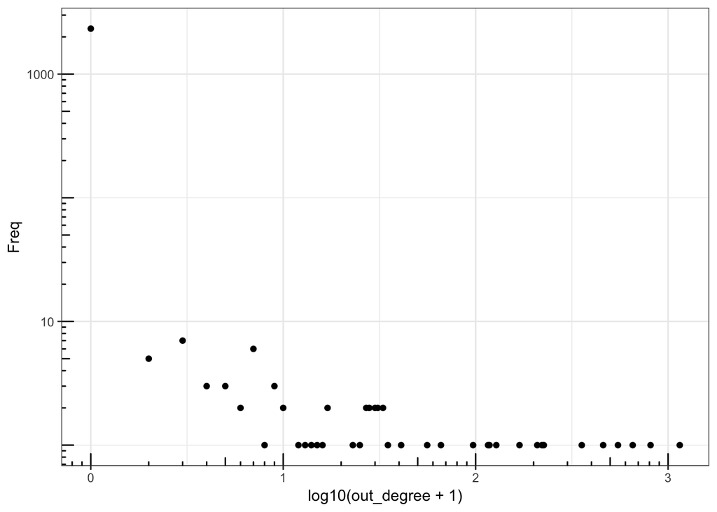

```r
out_degree_df <- as.data.frame(table(out_d)) %>%
 dplyr::rename(out_degree = out_d) %>%
 dplyr::mutate(out_degree = as.numeric(as.character(out_degree)))

ggplot(out_degree_df) + aes(x = log10(out_degree + 1), y = Freq) + geom_point() +
  scale_y_log10() +
  annotation_logticks(sides = "bl") + theme_bw()
```

```r
in_d <- degree(g,  mode = "in")

table(in_d)
```

```
## in_d
##    0    1    2    3    4    5    6    7    8    9   10   11   12   13   14
##   54 1221  485  228  132   74   60   29   23   16   11   10   10    3    7
##   15   17   18   19   20   21   22   23   25   26   29   30   31   33   34
##   10    5    5    2    1    1    1    3    1    1    1    2    1    1    1
##   36   42   59
##    1    1    1
```

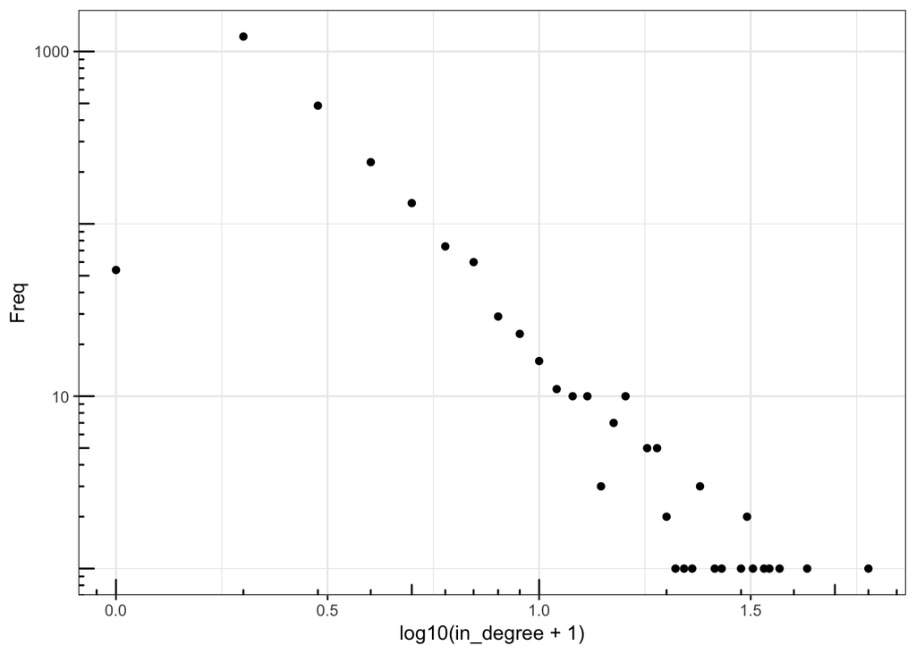

```r
in_degree_df <- as.data.frame(table(in_d)) %>%
  dplyr::rename(in_degree = in_d) %>%
  dplyr::mutate(in_degree = as.numeric(as.character(in_degree)))

ggplot(in_degree_df) + aes(x = log10(in_degree + 1), y = Freq) + geom_point() +
#   breaks = scales::trans_breaks("log10", function(x) 10^x),
#  scale_y_continuous("Frequency\n(how many of them)",
#   labels = scales::trans_format("log10", scales::math_format(10^.x))) + geom_smooth(method = "lm") +
#  scale_x_log10() +
  scale_y_log10() +
  annotation_logticks(sides = "bl") + theme_bw()
```

### In/Out Structure

Divide nodes into TF/Regulator and with in/out, in only (sink), out only (source)

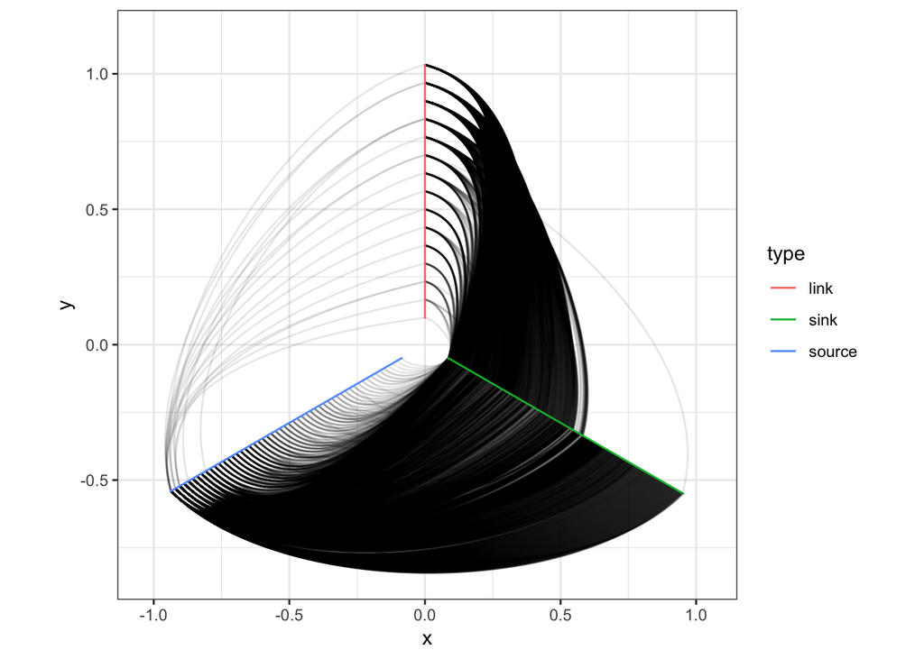

```r
tfs <- unique(interactions_df$TF_affy)
targets <- unique(interactions_df$Target_affy)

#V(g)$is_tf <- V(g)$name %in% tfs
#V(g)$is_target <- V(g)$name %in% targets

g <- g %>% activate(nodes) %>%
  mutate(is_tf = name %in% tfs) %>%
  mutate(out_degree = degree(g, mode = "out") ) %>%
  mutate(in_degree = degree(g, mode = "in") ) %>%
  mutate(type = if_else(out_degree == 0, "sink", if_else(in_degree == 0, "source", "link")))

ggraph(g, "hive", axis = "type", sort.by = "out_degree") +
  geom_edge_hive(alpha = 0.1) +
  geom_axis_hive(aes(colour = type), label = FALSE) + coord_fixed() + theme_bw()
```

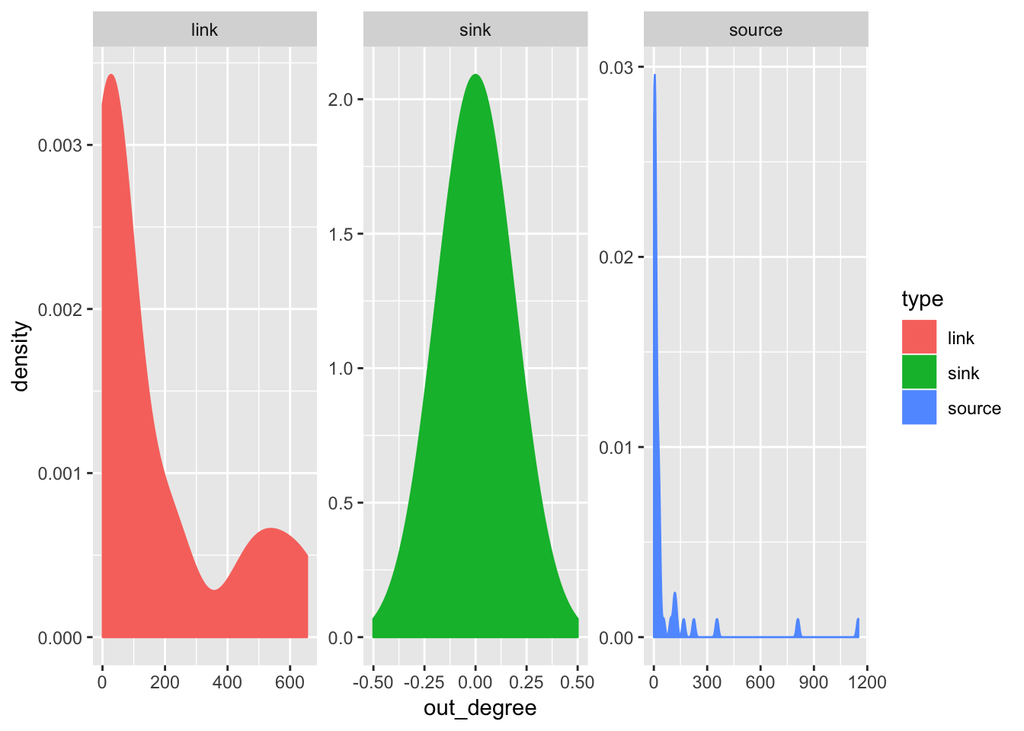

```r
g %>% activate(nodes) %>%
  as_tibble() %>%
  ggplot() + aes(out_degree) +
  geom_density(aes(colour= type, fill = type)) +
  facet_wrap( ~ type, scales = "free")
```

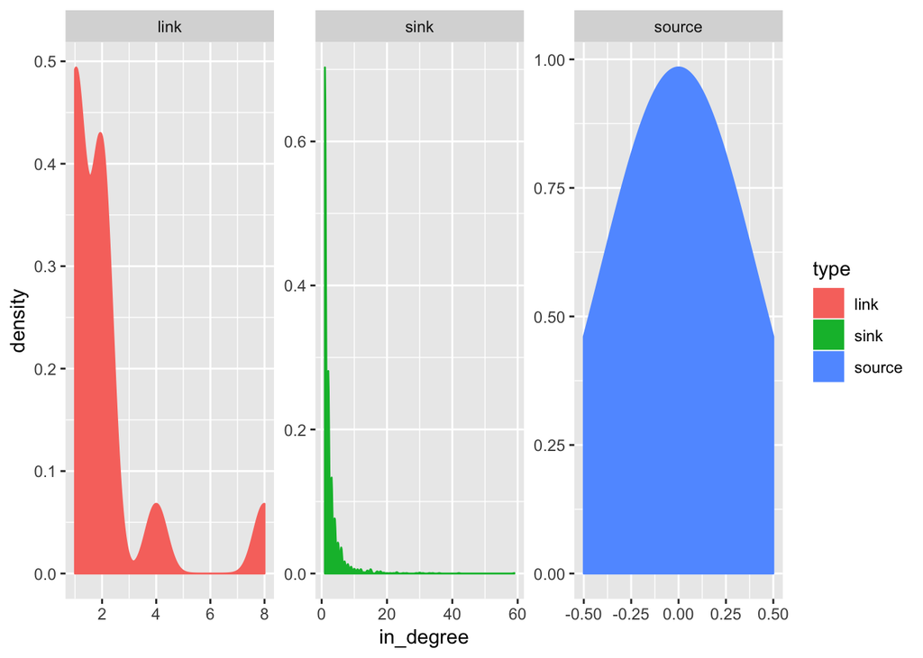

```r
g %>% activate(nodes) %>%
  as_tibble() %>%
  ggplot() + aes(in_degree) +
  geom_density(aes(colour= type, fill = type)) +
  facet_wrap( ~ type, scales = "free")
```

Actually, Im missing a step. This is really the wrong network to be doing this on. I need to work out which treatments the activation is happening in and analyse sub networks. Back to the drawing board!